# Manual de la Encuesta del Uso del Tiempo de los estadounidenses (ATUS)

Author

Ágatha Del Olmo Tirado

Published

October 22, 2025

# 0 - Introducción

En este trabajo se desarrolla un flujo completo para limpiar y preparar la encuesta ATUS, con el objetivo de analizar de manera integrada las dimensiones de actividad, sexo, edad y estado. Para ello, se utilizan múltiples métodos de obtención de datos:

- Descargas de forma manual desde fuentes abiertas en formatos semiestructurados (1.5. Descarga de los datos de los estados).
- Extracción ligera de información desde la web mediante Google Sheets (1.3. Descarga de la tabla de generaciones).
- Consultas a APIs públicas a través del paquete `blscrapeR` (2.4. Resultados relacionados con el estado) y de forma manual (1.1. Descarga de los microdatos de la encuesta ATUS, 1.2. Descarga del diccionario de actividades de la encuesta ATUS).

Este trabajo es especialmente relevante ya que permite aprovechar al máximo los datos de la encuesta ATUS, integrando diversas dimensiones sociodemográficas y destacando la gran utilidad de las encuestas cuando se procesan y analizan cuidadosamente. La combinación de APIs, fuentes semiestructuradas y extracción ligera desde la web posibilita el acceso a información actualizada y confiable, incluso en casos donde los datos no están disponibles bajo estándares de open data, mostrando la potencia de estos métodos en estudios estadísticos complejos.

# 1 - Limpieza de la Encuesta del Uso del Tiempo de los estadounidenses (ATUS)

La correcta limpieza de los datos es crucial en lo que respecta a las encuestas. Un mal uso de los pesos, una mala conversión de los datos, o incluso el efecto de los NAs pueden cambiar radicalmente los resultados estadísticos derivados de la encuesta.

Antes de empezar, se prepara el entorno de trabajo con todas las bibliotecas necesarias cargadas. Para ello, se define un vector que contiene los nombres de los paquetes que serán utilizados a lo largo del estudio, entre los que se incluyen herramientas para peticiones web API (httr, blscrapeR, jsonlite, xml2, xmlconvert), la manipulación y lectura de datos (dplyr, tidyr, tidyverse, readxl, openxlsx, readr, purrr) y para análisis espacial (sf, tmap, geodata, rgeoda, spatstat.geom, spatstat.explore), entre otras.

```r
pacman::p_load(
  httr,
  readxl,
  dplyr,
  tesseract,
  stringr,
  lubridate,
  tidyverse,
  tidyr,
  openxlsx,
  purrr,
  blscrapeR,
  sf,
  tmap,
  ggplot2,
  RColorBrewer,
  geodata,
  rgeoda,
  stringi,
  tidygeocoder,
  spatstat.geom,
  spatstat.explore,
  jsonlite,
  xml2,
  xmlconvert,
  fuzzyjoin,
  gridExtra,
  ggplot2
  )

conflicted::conflicts_prefer(lubridate::hour)
conflicted::conflicts_prefer(dplyr::filter)
```

## 1.1. Descarga de los microdatos de la encuesta ATUS

Primero se descargan los datos de la encuesta a través de la función `atus_csv_import()`. Esta función personalizada automatiza la descarga de datos directamente desde la web mediante una solicitud HTTP de tipo GET. Tras la descarga, la función descomprime el archivo, importa el fichero principal `.dat` a R, limpia los nombres de las variables y elimina los archivos temporales, devolviendo un conjunto de datos casi listo para su uso.

```r
atus_csv_import <-
  function( this_url ){

    this_tf <- tempfile()

    this_dl <- GET( this_url , user_agent( "email@address.com") )

    writeBin( content( this_dl ) , this_tf )

    unzipped_files <- unzip( this_tf , exdir = tempdir() )

    this_dat <- grep( '\\.dat$' , unzipped_files , value = TRUE )

    this_df <- read.csv( this_dat )

    file.remove( c( this_tf , unzipped_files ) )

    names( this_df ) <- tolower( names( this_df ) )

    this_df
  }
```

Para el presente análisis se utilizaron únicamente los conjuntos de datos de 2023 más relevantes:

- Archivo de actividades (act_df): Contiene el detalle de cada actividad realizada por los participantes durante el día del diario, incluyendo el código de actividad, la duración, la hora de inicio y fin, y otros atributos que permiten analizar el uso del tiempo a lo largo de la jornada.
- Archivo de información de los encuestados (resp_df): Proporciona los datos demográficos de cada participante, como edad, sexo y peso muestral, necesarios para ponderar los resultados y generar estimaciones representativas de la población estadounidense.
- Archivo de personas presentes durante las actividades (atuswho_df): Registra quiénes estuvieron presentes en cada actividad, lo que permite estudiar las relaciones sociales y familiares durante la jornada.
- Registro de miembros del hogar (atuscps_df): Incluye información sobre todos los miembros del hogar de los encuestados, incluyendo edad, sexo y estado civil.

Los demás archivos descargados, si bien forman parte del repositorio completo de la encuesta ATUS, no se emplearon en este estudio.

```r
act_df <- atus_csv_import("https://www.bls.gov/tus/datafiles/atusact-2023.zip")
resp_df <- atus_csv_import("https://www.bls.gov/tus/datafiles/atusresp-2023.zip")
rost_df <- atus_csv_import("https://www.bls.gov/tus/datafiles/atusrost-2023.zip")
wgts_df <- atus_csv_import("https://www.bls.gov/tus/datafiles/atuswgts-2023.zip")
atussum_df <- atus_csv_import("https://www.bls.gov/tus/datafiles/atussum-2023.zip")
atuswho_df <- atus_csv_import("https://www.bls.gov/tus/datafiles/atuswho-2023.zip")
atusrostec_df <- atus_csv_import("https://www.bls.gov/tus/datafiles/atusrostec-2023.zip")
atuscps_df <-atus_csv_import("https://www.bls.gov/tus/datafiles/atuscps-2023.zip")
```

## 1.2. Descarga del diccionario de actividades de la encuesta ATUS

Ahora, se descarga y procesa el diccionario de códigos de actividades de la encuesta ATUS correspondiente al año 2023, alojado en formato Excel en la web del BLS. Primero se define la URL del archivo y se crea un archivo temporal con extensión `.xls` para almacenar la descarga. La descarga se realiza mediante una solicitud GET, incluyendo un encabezado `User-Agent` que simula un navegador web, lo que permite que el servidor acepte la solicitud y cumpla con las buenas prácticas de acceso a recursos web.

```r
url_dictionary <- "https://www.bls.gov/tus/lexicons/lexiconwex2023.xls"
tf <- tempfile(fileext = ".xls")

GET(
  url_dictionary,
  write_disk(tf),
  add_headers(
    "User-Agent" = "Mozilla/5.0 (Windows NT 10.0; Win64; x64) AppleWebKit/537.36 (KHTML, like Gecko) Chrome/120.0.0.0 Safari/537.36"
  )
)
```

```
Response [https://www.bls.gov/tus/lexicons/lexiconwex2023.xls]
  Date: 2025-10-22 21:11
  Status: 200
  Content-Type: application/vnd.ms-excel
  Size: 248 kB
<ON DISK>  C:\Users\Portatil\AppData\Local\Temp\Rtmp8Supb9\file222c708b2951.xls
```

Una vez descargado, el archivo se lee, y se extraen únicamente las dos primeras columnas que contienen el código de la actividad y su descripción, generando un data frame limpio (`dictionary_df`) que servirá como referencia para interpretar los códigos de actividades en los análisis posteriores.

```r
dictionary_df <- readxl::read_excel(tf, sheet = 2) %>%
  select(1:2) %>%
  slice(-1) %>%
  rename(trcode = 1, descr = 2) %>%
  filter(!is.na(trcode), !is.na(descr))
```

Ahora, para contextualizar, en la encuesta, los participantes detallan todas las actividades realizadas desde las 04:00 a.m. del día anterior hasta las 04:00 a.m. del día de la entrevista, indicando los horarios de inicio y fin de cada una.

Sin embargo, al explorar los datos, se observa que las últimas actividades registradas no terminan exactamente a las 04:00 a.m., como sería esperable según el marco metodológico de la encuesta. Esto se puede comprobar mediante el siguiente fragmento de código, donde se filtran las últimas actividades de cada participante:

```r
act_df %>%
  group_by(tucaseid) %>%
  filter(tuactivity_n == max(tuactivity_n)) %>%
  select(tucaseid, tustoptime) %>%
  head()
```

```
# A tibble: 6 × 2
# Groups:   tucaseid [6]
  tucaseid tustoptime
     <dbl> <chr>
1  2.02e13 06:30:00
2  2.02e13 07:00:00
3  2.02e13 06:00:00
4  2.02e13 05:30:00
5  2.02e13 10:00:00
6  2.02e13 08:00:00
```

Se observa que algunas actividades finales aparecen con horas de finalización posteriores a las 04:00 a.m. (por ejemplo, 05:30 a.m. o incluso 10:00 a.m.). Esto implica que en la mayoría de casos la última actividad del día no se interrumpió de forma natural exactamente a las 04:00 a.m., momento en el que concluye oficialmente el diario de la encuesta.

Dado que buscamos recoger información correspondiente a un ciclo completo de 24 horas, desde las 04:00 a.m. del día anterior hasta las 04:00 a.m. del día de la entrevista, es necesario ajustar manualmente la hora de finalización de la última actividad.

Para corregir esto, primero, se crea el objeto `last_act`, que identifica la última actividad registrada por cada individuo:

```r
act_df$tucaseid <- as.character(act_df$tucaseid)
act_df$trcode <- as.character(act_df$trcode)

last_act <- act_df %>%
  group_by(tucaseid) %>%
  filter(tuactivity_n == max(tuactivity_n)) %>%
  select(tucaseid, tuactivity_n)
```

A continuación, se normalizan los códigos de actividad para mantener un formato uniforme con el diccionario, y se añaden las descripciones correspondientes a cada código, facilitando la interpretación de los datos.

Después, se identifica la última actividad de cada persona con `is_last = TRUE`. Esta marca permite aplicar la corrección: a todas las actividades finales se les asigna como hora de término `"04:00:00"`, cerrando así el periodo de observación de forma coherente.

```r
act_df_dictionary <- act_df %>%
  mutate(trcode = ifelse(nchar(trcode) == 5, paste0(0, trcode), trcode)) %>%
  filter(trcode %in% dictionary_df$trcode) %>%
  left_join(dictionary_df, by = "trcode") %>%
  select(tucaseid, trcode, tuactivity_n, tuactdur24, descr, tustarttim, tustoptime)
time_day <- act_df_dictionary %>%
  group_by(tucaseid, trcode, descr, tuactivity_n, tustarttim, tustoptime) %>%
  summarise(time = sum(tuactdur24), .groups = "drop_last") %>%
  mutate(tulineno = 1) %>%
  left_join(
    last_act %>% mutate(is_last = TRUE),
    by = c("tucaseid", "tuactivity_n")
    ) %>%
  mutate(is_last = ifelse(is.na(is_last), FALSE, is_last)) %>%
  mutate(tustoptime = ifelse(is_last, "04:00:00", tustoptime)) %>%
  select(-is_last)
```

Finalmente, se verifica que la duración total de las actividades por participante sume exactamente 24 horas:

```r
time_day %>%
  group_by(tucaseid) %>%
  summarise(h = sum(time)/60) %>%
  group_by(h) %>%
  count() %>%
  pull(h)
```

```
[1] 24
```

A continuación, se incorporan los pesos muestrales del ATUS con el fin de obtener resultados representativos de la población y evitar sesgos derivados de una muestra no ponderada. Estos pesos (`tufinlwgt`), incluidos en el archivo de encuestados (`resp_df`), ajustan las estimaciones para reflejar un “día promedio” de una persona en la población, corrigiendo diferencias por diseño muestral, no respuesta y distribución semanal.

```r
resp_df$tucaseid <- as.character(resp_df$tucaseid)

atussum_df_def <- resp_df %>%
  select(tucaseid, tufinlwgt)
```

## 1.3. Descarga de la tabla de generaciones

Con los pesos muestrales preparados, se construye el conjunto `individuals`, que reúne la información demográfica de los encuestados y se enriquece con una variable imputada que indica la generación a la que pertenece cada individuo. Para ello, se calcula el año de nacimiento restando la edad al año de referencia (2023) y se utiliza una tabla externa de generaciones (`generations_table`), obtenida de internet mediante la función de Google Sheets:

`=QUERY(IMPORTHTML("https://www.beresfordresearch.com/age-range-by-generation/", "table", 0))`

Esta permite importar automáticamente una tabla desde una página web y consultarla o filtrarla directamente dentro de la hoja de cálculo, facilitando la extracción y limpieza de datos en línea.

La tabla se limpia y transforma, separando los rangos de años de nacimiento en columnas (`born_start` y `born_end`) y añadiendo la generación más reciente, Gen Alpha (2013–2023). Luego, mediante una unión difusa, se asigna a cada individuo su generación correspondiente según su año de nacimiento.

```r
atuscps_df$tucaseid <- as.character(atuscps_df$tucaseid)

atuscps_df_ind <- atuscps_df %>%
  select(tucaseid, prtage, pesex, gestfips, pemaritl, tulineno) %>%
  mutate(sex = ifelse(pesex == 1, "Male", "Female"),
         age = prtage,
         birthday = 2023 - age,
         status =
           case_when(
             pemaritl == "1" ~ "Married - spouse present",
             pemaritl == "2" ~ "Married - spouse absent",
             pemaritl == "3" ~ "Widowed",
             pemaritl == "4" ~ "Widowed",
             pemaritl == "5" ~ "Separated",
             pemaritl == "6" ~ "Never Married",
             TRUE ~ NA_character_
           ),
         gestfips = ifelse(gestfips < 10, paste0("0", as.character(gestfips)), as.character(gestfips)))

generations_table <- read_xlsx("./generations_table.xlsx", sheet = 5) %>%
  mutate(
    generation = str_replace_all(`*Generations*`, "\\*", ""),
    Born = str_replace_all(`*Born*`, "–", "-")
  ) %>%
  separate(
    Born, into = c("born_start", "born_end"), sep = "-", convert = TRUE, extra = "drop"
  ) %>%
  mutate(
    born_start = str_trim(born_start),
    born_end = str_trim(born_end)
  ) %>%
  select(generation, born_start, born_end) %>%
  rbind(c("Gen Alpha", 2013, 2023))


state_labels <- tibble::tibble(
  gestfips = c(
    "01","02","04","05","06","08","09","10","11","12","13","15",
    "16","17","18","19","20","21","22","23","24","25","26","27",
    "28","29","30","31","32","33","34","35","36","37","38","39","40",
    "41","42","44","45","46","47","48","49","50","51","53","54","55","56"
  ),
  region = c(
    "AL","AK","AZ","AR","CA","CO","CT","DE","DC","FL","GA","HI",
    "ID","IL","IN","IA","KS","KY","LA","ME","MD","MA","MI","MN",
    "MS","MO","MT","NE","NV","NH","NJ","NM","NY","NC","ND","OH","OK",
    "OR","PA","RI","SC","SD","TN","TX","UT","VT","VA","WA","WV","WI","WY"
  )
)

individuals <- atuscps_df_ind %>%
  fuzzy_left_join(
    generations_table,
    by = c("birthday" = "born_start", "birthday" = "born_end"),
    match_fun = list(`>=`, `<=`)
  ) %>%
  left_join(state_labels) %>%
  left_join(atussum_df_def) %>%
  select(-gestfips, -pemaritl, -birthday, -pesex, -prtage, -born_start, -born_end)
```

Además, se incluye el archivo `atuswho_df`, que identifica con quién realiza cada actividad el encuestado. Primero, se traduce el código numérico `tuwho_code` en descripciones legibles, y se agrupan en categorías más amplias (`category`), como *“Partner”*, *“Children”* o *“Family”*.

En caso de que una misma actividad involucre a varias personas, sus nombres se combinan en una sola cadena separada por punto y coma, lo que evita duplicar filas y facilita el trabajo posterior al mantener una sola fila por actividad.

```r
atuswho_df$tucaseid <- as.character(atuswho_df$tucaseid)

atuswho_df_def <- atuswho_df %>%
  mutate(who =
           case_when(
             tuwho_code == 18 ~ "Alone",
             tuwho_code == 19 ~ "Alone",
             tuwho_code == 20 ~ "Spouse",
             tuwho_code == 21 ~ "Unmarried partner",
             tuwho_code == 22 ~ "Own household child",
             tuwho_code == 23 ~ "Grandchild",
             tuwho_code == 24 ~ "Parent",
             tuwho_code == 25 ~ "Brother/sister",
             tuwho_code == 26 ~ "Other related person",
             tuwho_code == 27 ~ "Foster child",
             tuwho_code == 28 ~ "Housemate/roommate",
             tuwho_code == 29 ~ "Roomer/boarder",
             tuwho_code == 30 ~ "Other nonrelative",
             tuwho_code == 40 ~ "Own nonhousehold child < 18",
             tuwho_code == 51 ~ "Parents (not living in household)",
             tuwho_code == 52 ~ "Other nonhousehold family members < 18",
             tuwho_code == 53 ~ "Other nonhousehold family members 18 and older (including parents-in-law)",
             tuwho_code == 54 ~ "Friends",
             tuwho_code == 56 ~ "Neighbors/acquaintances",
             tuwho_code == 57 ~ "Other nonhousehold children < 18",
             tuwho_code == 58 ~ "Other nonhousehold adults 18 and older",
             tuwho_code == 59 ~ "Boss or manager",
             tuwho_code == 60 ~ "People whom I supervise",
             tuwho_code == 61 ~ "Co-workers",
             tuwho_code == 62 ~ "Customers",
             TRUE ~ NA_character_
           ),
         category = case_when(
           tuwho_code %in% c(18, 19) ~ "Alone",
           tuwho_code %in% c(20, 21) ~ "Partner",
           tuwho_code %in% c(22, 23, 27, 40, 52) ~ "Children",
           tuwho_code %in% c(24, 25, 26, 51, 53) ~ "Family",
           tuwho_code %in% c(28, 29, 54) ~ "Friend",
           tuwho_code %in% c(55, 59, 60, 61) ~ "Co-worker",
           tuwho_code %in% c(30, 56, 57, 58, 62) ~ "Other",
           TRUE ~ NA_character_
           )
  ) %>%
  select(-tuwho_code, -trwhona) %>%
  group_by(tucaseid, tuactivity_n, category) %>%
  summarise(who = ifelse(n_distinct(who) == 1, first(who), (paste(unique(who), collapse = ";"))),
            category = ifelse(n_distinct(category) == 1, first(category), (paste(unique(category), collapse = ";"))),
            .groups = "drop")
```

Una vez generado el dataframe `atuswho_df_def`, se realiza una verificación para asegurar que la columna `category` no contenga combinaciones múltiples de categorías. Es decir, en lugar de valores como *“Parent;Brother/sister”*, ahora se unifican bajo una sola categoría más general, como *“Family”*. Este proceso simplifica considerablemente el análisis posterior.

```r
atuswho_df_def %>% filter(str_detect(category, ";"))
```

```
# A tibble: 0 × 4
# ℹ 4 variables: tucaseid <chr>, tuactivity_n <int>, category <chr>, who <chr>
```

Toda la información procesada se integra en un único conjunto de datos denominado `combined`, en el que se combinan las tablas de actividades y sus horas (`time_day`), personas presentes (`atuswho_df_def`) y características individuales (`individuals`). Además, se convierte la duración de las actividades de minutos a horas para facilitar su análisis temporal:

```r
combined <- time_day %>%
  left_join(atuswho_df_def) %>%
  left_join(individuals) %>%
  mutate(time_h = time/60) %>%
  select(-tulineno)

combined %>% head()
```

```
# A tibble: 6 × 16
# Groups:   tucaseid, trcode, descr, tuactivity_n, tustarttim [6]
  tucaseid  trcode descr tuactivity_n tustarttim tustoptime  time category who
  <chr>     <chr>  <chr>        <int> <chr>      <chr>      <int> <chr>    <chr>
1 20230101… 010101 Slee…            1 04:00:00   08:00:00     240 <NA>     <NA>
2 20230101… 010101 Slee…           19 22:35:00   04:00:00     325 <NA>     <NA>
3 20230101… 010201 Wash…           18 22:25:00   22:35:00      10 <NA>     <NA>
4 20230101… 020201 Food…            5 10:40:00   10:50:00      10 Alone    Alone
5 20230101… 020201 Food…           15 19:45:00   20:25:00      40 Alone    Alone
6 20230101… 020901 Fina…           17 20:55:00   22:25:00      90 Alone    Alone
# ℹ 7 more variables: sex <chr>, age <int>, status <chr>, generation <chr>,
#   region <chr>, tufinlwgt <dbl>, time_h <dbl>
```

## 1.4. Descarga de la tabla de clasificaciones de las actividades

A continuación, se descargan las clasificaciones oficiales de las actividades del ATUS, publicadas por la propia BLS, a través de una solicitud tipo API GET.

```r
url_dictionary_categories <- "https://www.bls.gov/tus/coderules/tu2023coderules.pdf"

GET(
  url_dictionary_categories,
  write_disk(tf, overwrite = TRUE),
  add_headers(
    "User-Agent" = "Mozilla/5.0 (Windows NT 10.0; Win64; x64) AppleWebKit/537.36 (KHTML, like Gecko) Chrome/120.0.0.0 Safari/537.36"
  )
)
```

```
Response [https://www.bls.gov/tus/coderules/tu2023coderules.pdf]
  Date: 2025-10-22 21:11
  Status: 200
  Content-Type: application/pdf
  Size: 462 kB
<ON DISK>  C:\Users\Portatil\AppData\Local\Temp\Rtmp8Supb9\file222c708b2951.xls
```

Dado que el archivo está en formato PDF, se convierte a imagen (`pdf_convert`) y se extrae el texto mediante reconocimiento óptico de caracteres (OCR). Posteriormente, se limpian las líneas, eliminando caracteres no deseados y separando los códigos de actividad de sus descripciones para generar una tabla estructurada.

```r
png_file <- pdftools::pdf_convert(tf, pages = 2, dpi = 600)
```

```
Converting page 2 to file222c708b2951.xls_2.png...
```

```
 done!
```

```r
text <- tesseract::ocr(png_file)

cat(text)
```

```
TABLE OF CONTENTS

Major Code/Activity Category Page number
MISCELLANEOUS RULES 4
01 PERSONAL CARE 15
02 HOUSEHOLD ACTIVITIES 16
03 CARING FOR AND HELPING HOUSEHOLD MEMBERS 21
04 CARING FOR AND HELPING NONHOUSEHOLD MEMBERS 24
05 WORK AND WORK-RELATED ACTIVITIES 27
06 EDUCATION 29
07 CONSUMER PURCHASES 31
08 PROFESSIONAL AND PERSONAL CARE SERVICES 33
09 HOUSEHOLD SERVICES 34
10 GOVERNMENT SERVICES AND CIVIC OBLIGATIONS 35
11 EATING AND DRINKING 36
12 SOCIALIZING, RELAXING, AND LEISURE 37
13 SPORTS, EXERCISE, AND RECREATION 42
14 RELIGIOUS AND SPIRITUAL ACTIVITIES 44
15 VOLUNTEER ACTIVITIES 46
16 TELEPHONE CALLS 48
18 TRAVELING 49
50 DATA CODES 55

2
```

```r
lines <- strsplit(text, "\n")[[1]]

clean_lines <- lines[5:21]

lines_df <- data.frame(raw = clean_lines) %>%
  mutate(
    code = str_extract(raw, "^[0-9]{2}"),
    desc = str_trim(str_remove(raw, "^[0-9]{2}\\s+")),
    desc = str_remove(desc, "\\s+[0-9]+$")
  ) %>%
  select(code, desc)
```

Esta tabla se incorpora al conjunto combined creado previamente, asociando cada actividad a su categoría descriptiva. Además, se elimina el código “50”, correspondiente a la no respuesta, y se convierten las variables de inicio y fin de actividad a formato horario legible.

```r
combined_classified <- combined %>%
  mutate(code = substr(trcode, 1, 2)) %>%
  left_join(lines_df) %>%
  filter(code != "50")


combined_classified <- combined_classified %>%
  mutate(
    start_hour = hour(hms(tustarttim)) + minute(hms(tustarttim))/60,
    end_hour   = hour(hms(tustoptime)) + minute(hms(tustoptime))/60
  )
```

Sin embargo, como se ha comentado previamente, las actividades en el ATUS se registran desde las 04:00 a.m. del día anterior hasta las 04:00 a.m. Para adaptar estos datos a un ciclo de 24 horas convencional (de 00:00 a 00:00) se identifican todas las actividades cuyo tiempo de finalización (`end_hour`) es menor que el de inicio (`start_hour`), ya que esto indica que cruzan la medianoche.

De esta forma se generan dos pares de valores:

- `start1–end1`, que representa la parte de la actividad antes de medianoche (desde la hora de inicio hasta las 23:59).
- `start2–end2`, que representa la parte posterior (desde las 00:00 hasta la hora original de finalización).

Se reorganiza la tabla para duplicar las filas de cada actividad que cruza medianoche, convirtiendo los pares de tiempos en registros separados. Y así, el conjunto de datos resultante refleja de manera precisa la distribución temporal de todas las actividades dentro de un mismo día, asegurando que cada individuo tenga exactamente 24 horas de registro sin solapamientos ni inconsistencias.

```r
no_midnight <- combined_classified %>%
  filter(end_hour >= start_hour) %>%
  mutate(start = start_hour, end = end_hour)

cross_midnight <- combined_classified %>%
  filter(end_hour < start_hour) %>%
  mutate(start1 = start_hour,
         end1   = 23.99,
         start2 = 0,
         end2   = end_hour) %>%
  pivot_longer(cols = c(start1, start2), values_to = "start") %>%
  mutate(end = ifelse(name == "start1", 23.99, end2)) %>%
  select(-name, -end2)

combined_hours <- bind_rows(no_midnight, cross_midnight)

combined_classified_2 <- combined_hours %>%
  mutate(
    hours_list = map2(start, end, ~ floor(seq(.x, .y, by = 1)))
  )
```

## 1.5. Descarga de los datos de los estados

Finalmente, se descargan los datos geográficos de los estados de EE.UU. en formato `.json`, concretamente en un archivo GeoJSON que se han descargado de la web `gadm.org`. Este formato es una extensión del estándar JSON diseñada para almacenar información geoespacial de una forma legible y fácilmente explotable con distintos entornos GIS (Sistemas de Información Geográfica).

```r
usa_sf <- st_read("./gadm41_USA_1.json")
```

La función `st_transform(crs = 4326)` se utiliza para convertir las geometrías al sistema de coordenadas geográficas WGS84, que es el estándar más común en análisis y visualización espacial. A continuación, se excluyen los estados de Hawái (`US-HI`) y Alaska (`US-AK`), ya que carecen de vecinos espaciales, lo que imposibilitaría la aplicación de métodos de análisis basados en relaciones de vecindad.

```r
atus_usa_sf <- combined_classified %>%
  filter(code == "12") %>%
  group_by(region) %>%
  summarise(
    value = sum(time_h * tufinlwgt, na.rm = TRUE) / sum(tufinlwgt, na.rm = TRUE),
    .groups = "drop"
  ) %>%
  mutate(ISO_1 = paste0("US-", region)) %>%
  left_join(usa_sf[, c("ISO_1", "NAME_1", "geometry")]) %>%
  st_as_sf() %>%
  st_transform(crs = 4326) %>%
  filter(!ISO_1 %in% c("US-HI", "US-AK"))
```

# 2. Resultados de la encuesta

Tras completar el proceso de limpieza y estandarización de los datos, se procede a obtener los resultados derivados de la encuesta, centrados en sus principales dimensiones analíticas: actividades, sexo, edad y estado de residencia.

## 2.1. Resultados relacionados con las actividades

En primer lugar, se analiza la distribución temporal de las actividades. Para ello, se genera un “reloj de actividades”, una visualización que muestra, hora a hora, la actividad en la que se encuentra el mayor número de personas. Este enfoque permite captar de forma intuitiva los patrones diarios de comportamiento y facilita la interpretación de los ritmos sociales a lo largo del día.

Para ello, se desanidan las horas de cada actividad (ya que sus horas estaban guardadas en una variable tipo lista) y se agrupan los datos por tipo de actividad y hora, sumando los pesos muestrales que representan el número estimado de personas que la realizan.

```r
num_participants <- combined_classified_2 %>%
  unnest(hours_list) %>%
  mutate(hour = hours_list) %>%
  group_by(descr, hour) %>%
  summarise(
    numj = sum(tufinlwgt, na.rm = TRUE),
    .groups = "drop"
  )
```

A continuación, para cada hora se identifica la actividad con el mayor valor ponderado, construyendo un “reloj de actividades” que ilustra los momentos del día en los que cada tipo de actividad es más frecuente, tal como se visualiza en el gráfico elaborado para este análisis.

```r
max_hours <- num_participants %>%
  group_by(hour) %>%
  slice_max(numj, n = 1, with_ties = FALSE) %>%
  ungroup()

max_hours
```

```
# A tibble: 24 × 3
   descr           hour          numj
   <chr>          <dbl>         <dbl>
 1 Sleeping           0  90572252943.
 2 Sleeping           1  94265031682.
 3 Sleeping           2  95948462645.
 4 Sleeping           3  96376256619.
 5 Sleeping           4 175709882073.
 6 Sleeping           5  89086215573.
 7 Sleeping           6  78552834497.
 8 Sleeping           7  57526510456.
 9 Sleeping           8  36522062369.
10 Work, main job     9  36894883857.
# ℹ 14 more rows
```

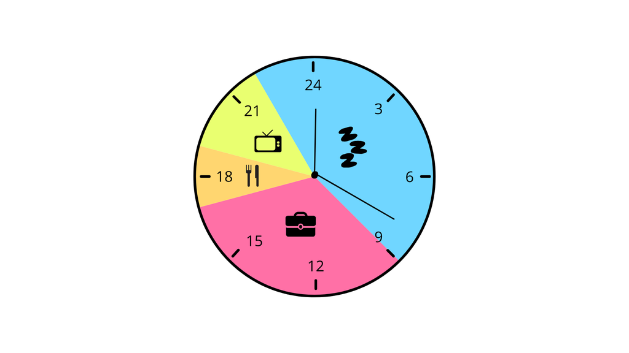

**A tener en cuenta…**

Los resultados presentados no reflejan necesariamente cómo transcurre un día típico de un estadounidense, sino que únicamente muestran cuál es la actividad predominante en cada hora según los datos de la encuesta. Por ejemplo, aunque la actividad de comer aparezca únicamente en las horas de la cena, esto no significa que no se realicen comidas en otros momentos del día; simplemente indica que, en promedio y ponderando por los participantes, no es la actividad más común en esas otras franjas horarias.

## 2.2. Resultados relacionados con el sexo

A continuación se analizan las diferencias entre hombres y mujeres en el tiempo dedicado al cuidado de los niños (actividad con código `030101`).

Primero, se filtran las observaciones correspondientes a esa actividad y se desanidan las horas. Luego, se agrupa por sexo y hora, sumando los pesos muestrales para estimar el número ponderado de personas que estuvieron realizando esa actividad en cada hora del día.

A continuación, se agrupan los resultados por sexo y se suman los valores totales de tiempo ponderado, calculando finalmente el porcentaje que representa cada sexo respecto al total.

```r
activity_030101 <- combined_classified_2 %>%
  filter(trcode == "030101") %>%
  unnest(hours_list) %>%
  mutate(hour = hours_list) %>%
  group_by(sex, hour) %>%
  summarise(
    numj = sum(tufinlwgt, na.rm = TRUE),
    .groups = "drop"
  )

total_hours_by_sex <- activity_030101 %>%
  group_by(sex) %>%
  summarise(total_hours = sum(numj), .groups = "drop")

percent <- total_hours_by_sex %>%
  mutate(percentage = 100 * total_hours / sum(total_hours)) %>%
  select(-total_hours)
```

Los resultados muestran que las mujeres realizan aproximadamente el 66% del tiempo dedicado al cuidado infantil, mientras que los hombres representan cerca del 33%, lo que evidencia una clara desigualdad de género en la distribución de esta tarea doméstica y de cuidados.

```r
percent
```

```
# A tibble: 2 × 2
  sex    percentage
  <chr>       <dbl>
1 Female       67.0
2 Male         33.0
```

## 2.3. Resultados relacionados con la edad

A continuación, se analiza con quiénes pasan su tiempo las personas según su etapa de vida, explorando cómo varían las interacciones sociales y los entornos de convivencia a lo largo de la adolescencia, la adultez y la tercera edad.

Para ello, se agrupa por edad (`age`) y categoría de compañía (`category`), sumando los pesos muestrales para obtener el número total de “horas ponderadas” dedicadas a cada categoría, y se clasifica cada individuo en una etapa de la vida (`age_stage`) según su edad. Se agrupa por etapa de vida y categoría de compañía, sumando las horas ponderadas, y luego se calcula el porcentaje que representa cada categoría respecto al total de horas dentro de cada grupo.

```r
combined_who <- combined_classified_2 %>%
  unnest(hours_list) %>%
  mutate(hour = hours_list) %>%
  group_by(age, category) %>%
  summarise(
    numj = sum(tufinlwgt, na.rm = TRUE),
    .groups = "drop"
  )

# Total de horas por sexo (ponderadas)
combined_who_grouped <- combined_who %>%
  filter(!is.na(category)) %>%
  mutate(
    age_stage = case_when(
      age < 20 ~ "Adolescence",
      age >= 20 & age < 45 ~ "Early Adulthood",
      age >= 45 & age < 65 ~ "Middle Adulthood",
      age >= 65 ~ "Late Adulthood",
      TRUE ~ NA_character_
    )
  ) %>%
  group_by(age_stage, category) %>%
  summarise(numj = sum(numj)) %>%
  mutate(percentage = 100 * numj / sum(numj)) %>%
  select(-numj)

combined_who_grouped
```

```
# A tibble: 28 × 3
# Groups:   age_stage [4]
   age_stage       category  percentage
   <chr>           <chr>          <dbl>
 1 Adolescence     Alone         48.8
 2 Adolescence     Children       2.04
 3 Adolescence     Co-worker      4.87
 4 Adolescence     Family        26.6
 5 Adolescence     Friend         8.25
 6 Adolescence     Other          8.84
 7 Adolescence     Partner        0.659
 8 Early Adulthood Alone         36.9
 9 Early Adulthood Children      18.5
10 Early Adulthood Co-worker     11.3
# ℹ 18 more rows
```

La gráfica elaborada revela patrones claros en la compañía de las personas a lo largo de la vida, mostrando cómo las relaciones y prioridades cambian según la etapa.

**Mostrar código**

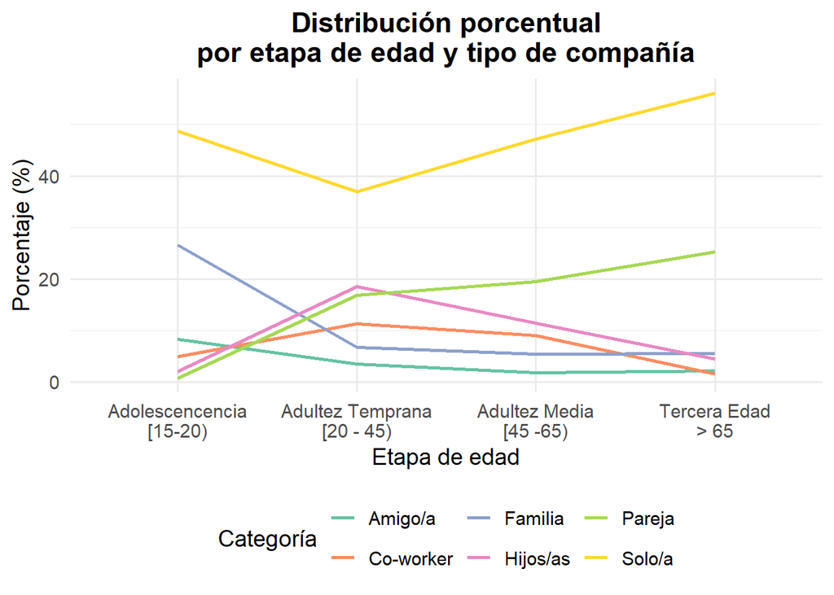

```r
combined_who_grouped_plot <- combined_who_grouped %>%
  filter(category != "Other") %>%
  mutate(
    age_stage = case_when(
      age_stage == "Adolescence" ~ "Adolescencencia\n[15-20)",
      age_stage == "Early Adulthood" ~ "Adultez Temprana\n[20 - 45)",
      age_stage == "Middle Adulthood" ~ "Adultez Media\n[45 -65)",
      age_stage == "Late Adulthood" ~ "Tercera Edad\n> 65"
      ),
    category = case_when(
      category == "Alone" ~ "Solo/a",
      category == "Children" ~ "Hijos/as",
      category == "Co-worker" ~ "Co-worker",
      category == "Family" ~ "Familia",
      category == "Friend" ~ "Amigo/a",
      category == "Partner" ~ "Pareja",
      )
  )


combined_who_grouped_plot$age_stage <- factor(
  combined_who_grouped_plot$age_stage,
  levels = c("Adolescencencia\n[15-20)",
             "Adultez Temprana\n[20 - 45)",
             "Adultez Media\n[45 -65)",
             "Tercera Edad\n> 65")
)


ggplot(combined_who_grouped_plot, aes(x = age_stage, y = percentage, group = category, color = category)) +
  geom_line(size = 1) +
  scale_color_brewer(palette = "Set2") +
  labs(
    title = "Distribución porcentual\npor etapa de edad y tipo de compañía",
    x = "Etapa de edad",
    y = "Porcentaje (%)",
    color = "Categoría"
  ) +
  theme_minimal(base_size = 14) +
  theme(
    plot.title = element_text(face = "bold", hjust = 0.5),
    legend.position = "bottom"
  )
```

## 2.4. Resultados relacionados con el estado

En este último apartado se analiza la relación entre los niveles de empleo y el tiempo dedicado al relax y la socialización en los distintos estados de Estados Unidos. Aunque podría suponerse que un mayor empleo conlleva menos tiempo libre, esta relación no necesariamente es directa y puede variar según la estructura económica, las políticas laborales y las características demográficas de cada región.

Para explorar cómo se relacionan estas variables se obtiene la información de empleo estatal a través de la API del Bureau of Labor Statistics (BLS), combinando los identificadores de serie correspondientes a cada estado y sector económico. Una vez recopilados y consolidados los datos, estos se vinculan con las geometrías de los estados mediante el archivo en formato GeoJSON previamente preparado.

```r
state_codes <- sprintf("SMS%02d0000", 1:56)

sector_codes <- c(
  "00000000001", "01000000001", "01500000001", "02000000001",
  "03000000001", "04000000001", "05000000001", "05500000001",
  "06000000001", "06500000001", "07000000001", "08000000001",
  "09000000001"
)

series_ids <- as.vector(outer(state_codes, sector_codes, paste0))

series_chunks <- split(series_ids, ceiling(seq_along(series_ids)/50))

key_bls <- "614e810928db44649b4634edf7526800" # mi clave API

df_list <- lapply(series_chunks, function(chunk){
  bls_api(
    seriesid = chunk,
    startyear = 2023,
    endyear = 2023,
    registrationKey = key_bls
  )
})

df_states_employment <- do.call(rbind, df_list)

# df_states_employment <- read_excel("./df_states_employment.xlsx")
# Si no funciona la API
```

Posteriormente, se aplican transformaciones de coordenadas para asegurar la compatibilidad con sistemas cartográficos estándar y se excluyen los estados de Alaska y Hawái por las razones mencionadas previamente.

```r
df_states_employment <-
  df_states_employment %>%
  mutate(gestfips = substr(seriesID, 4, 5)) %>%
  left_join(state_labels) %>%
  group_by(region) %>%
  summarise(value = sum(value))


datos_usa_sf <- df_states_employment %>%
  mutate(ISO_1 = paste0("US-", region)) %>%
  left_join(usa_sf[, c("ISO_1", "NAME_1", "geometry")]) %>%
  st_as_sf() %>%
  st_transform(crs = 4326) %>%
  filter(!ISO_1 %in% c("US-HI", "US-AK"))

atus_usa_sf <- combined_classified %>%
  filter(code == "12") %>%
  group_by(region) %>%
  summarise(
    value = sum(time_h * tufinlwgt, na.rm = TRUE) / sum(tufinlwgt, na.rm = TRUE),
    .groups = "drop"
  ) %>%
  mutate(ISO_1 = paste0("US-", region)) %>%
  left_join(usa_sf[, c("ISO_1", "NAME_1", "geometry")]) %>%
  st_as_sf() %>%
  st_transform(crs = 4326) %>%
  filter(!ISO_1 %in% c("US-HI", "US-AK"))
```

Con los datos listos, se construyen matrices de pesos espaciales, identificando qué estados comparten fronteras. Esto permite calcular el índice de autocorrelación espacial de Moran, con el fin de evaluar si los valores presentan un patrón de concentración geográfica o aleatorio.

El análisis muestra valores cercanos a cero y p-valores elevados para ambas variables,lo que sugiere que no hay una autocorrelación espacial significativa entre los estados. Es decir, los estados con mayor/menor empleo no tienden a agruparse geográficamente, y lo mismo se observa para la variable de relax.

```r
wr <- spdep::poly2nb(datos_usa_sf, queen = FALSE)
ww <- spdep::nb2listw(wr, style = "W", zero.policy = TRUE)

spdep::moran.test(datos_usa_sf$value, listw=ww)
```

```
    Moran I test under randomisation

data:  datos_usa_sf$value
weights: ww

Moran I statistic standard deviate = 0.14229, p-value = 0.4434
alternative hypothesis: greater
sample estimates:
Moran I statistic       Expectation          Variance
     -0.007992297      -0.020833333       0.008143805
```

```r
wr <- spdep::poly2nb(atus_usa_sf, queen = FALSE)
ww <- spdep::nb2listw(wr, style = "W", zero.policy = TRUE)

spdep::moran.test(atus_usa_sf$value, listw=ww)
```

```
    Moran I test under randomisation

data:  atus_usa_sf$value
weights: ww

Moran I statistic standard deviate = 0.11927, p-value = 0.4525
alternative hypothesis: greater
sample estimates:
Moran I statistic       Expectation          Variance
     -0.009153996      -0.020833333       0.009588617
```

De la misma forma, la nube de puntos del gráfico de dispersión de Moran no presenta una tendencia definida, confirmando la ausencia de autocorrelación espacial observada en el test.

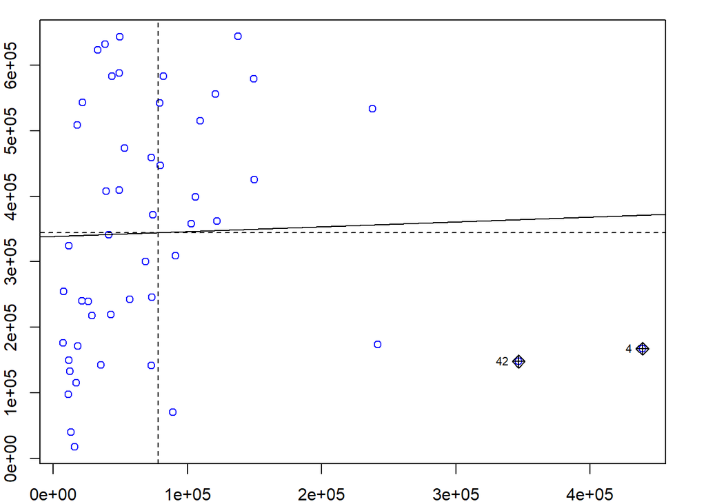

```r
par(mar = c(2,2,1,2))
spdep::moran.plot(datos_usa_sf$value,listw=spdep::nb2listw(wr, style = "B"), col="blue")
```

```r
datos_usa_sf[42,]
```

```
Simple feature collection with 1 feature and 4 fields
Geometry type: MULTIPOLYGON
Dimension:     XY
Bounding box:  xmin: -106.6458 ymin: 25.8381 xmax: -93.5087 ymax: 36.5034
Geodetic CRS:  WGS 84
# A tibble: 1 × 5
  region   value ISO_1 NAME_1                                           geometry
  <chr>    <dbl> <chr> <chr>                                  <MULTIPOLYGON [°]>
1 TX     346596. US-TX Texas  (((-97.2757 26.2371, -97.274 26.2332, -97.2637 26…
```

```r
datos_usa_sf[4,]
```

```
Simple feature collection with 1 feature and 4 fields
Geometry type: MULTIPOLYGON
Dimension:     XY
Bounding box:  xmin: -124.4156 ymin: 32.5309 xmax: -114.1295 ymax: 42.0098
Geodetic CRS:  WGS 84
# A tibble: 1 × 5
  region   value ISO_1 NAME_1                                           geometry
  <chr>    <dbl> <chr> <chr>                                  <MULTIPOLYGON [°]>
1 CA     438900. US-CA California (((-117.233 32.7742, -117.2336 32.7719, -117.…
```

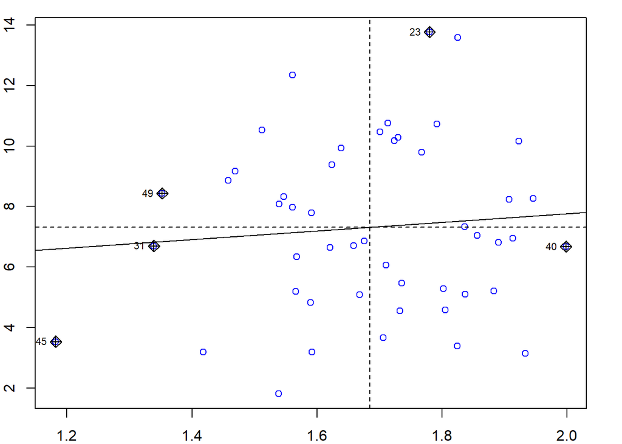

```r
par(mar = c(2,2,1,2))
spdep::moran.plot(atus_usa_sf$value,listw=spdep::nb2listw(wr, style = "B"), col="blue")
```

```r
atus_usa_sf[23,]
```

```
Simple feature collection with 1 feature and 4 fields
Geometry type: MULTIPOLYGON
Dimension:     XY
Bounding box:  xmin: -95.7744 ymin: 35.9951 xmax: -89.1006 ymax: 40.614
Geodetic CRS:  WGS 84
# A tibble: 1 × 5
  region value ISO_1 NAME_1                                             geometry
  <chr>  <dbl> <chr> <chr>                                    <MULTIPOLYGON [°]>
1 MO      1.78 US-MO Missouri (((-90.1259 35.9979, -90.2574 35.9975, -90.3773 3…
```

```r
atus_usa_sf[45,]
```

```
Simple feature collection with 1 feature and 4 fields
Geometry type: MULTIPOLYGON
Dimension:     XY
Bounding box:  xmin: -73.4434 ymin: 42.7276 xmax: -71.4677 ymax: 45.0163
Geodetic CRS:  WGS 84
# A tibble: 1 × 5
  region value ISO_1 NAME_1                                             geometry
  <chr>  <dbl> <chr> <chr>                                    <MULTIPOLYGON [°]>
1 VT      1.18 US-VT Vermont (((-72.9302 42.738, -73.2754 42.7456, -73.2916 42.…
```

```r
atus_usa_sf[31,]
```

```
Simple feature collection with 1 feature and 4 fields
Geometry type: MULTIPOLYGON
Dimension:     XY
Bounding box:  xmin: -109.05 ymin: 31.3328 xmax: -103.0007 ymax: 36.9994
Geodetic CRS:  WGS 84
# A tibble: 1 × 5
  region value ISO_1 NAME_1                                             geometry
  <chr>  <dbl> <chr> <chr>                                    <MULTIPOLYGON [°]>
1 NM      1.34 US-NM NewMexico (((-107.0006 31.784, -108.2084 31.7838, -108.208…
```

```r
atus_usa_sf[40,]
```

```
Simple feature collection with 1 feature and 4 fields
Geometry type: MULTIPOLYGON
Dimension:     XY
Bounding box:  xmin: -104.0571 ymin: 42.4811 xmax: -96.4366 ymax: 45.9439
Geodetic CRS:  WGS 84
# A tibble: 1 × 5
  region value ISO_1 NAME_1                                             geometry
  <chr>  <dbl> <chr> <chr>                                    <MULTIPOLYGON [°]>
1 SD      2.00 US-SD SouthDakota (((-97.6688 42.8311, -97.6822 42.8335, -97.692…
```

**Mostrar código**

```r
match_palette <- function(patterns, classifications, colors){
  classes_present <- unique(patterns)
  mat <- matrix(c(classifications, colors), ncol = 2)
  logi <- classifications %in% classes_present
  pre_col <- matrix(mat[logi], ncol = 2)
  pal <- pre_col[, 2]
  return(pal)
}

lisa_map <- function(df, lisa, alpha = .05) {
  clusters <- lisa_clusters(lisa, cutoff = alpha)
  labels <- lisa_labels(lisa)
  colors <- lisa_colors(lisa)
  lisa_patterns <- labels[clusters + 1]
  pal <- match_palette(lisa_patterns, labels, colors)
  labels <- labels[labels %in% lisa_patterns]
  df["lisa_clusters"] <- clusters

  mapa_base <- tm_shape(df) +
    tm_fill(col = "gray90") +
    tm_borders(col = "white", lwd = 0.5)

  capa_clusters <- tm_shape(df) +
    tm_fill("lisa_clusters", labels = labels, palette = pal, style = "cat", alpha = 0.7, colorNA = "white") +
    tm_borders(col = "white", lwd = 0.5)

  mapa_base +
    capa_clusters +
    tm_layout(
      bg.color = "white",
      frame = FALSE,
      legend.outside = TRUE,
      legend.outside.position = "right",
      legend.title.size = 1,
      legend.text.size = 0.8,
      fontfamily = "sans"
    )
}

significance_map <- function(df, lisa, permutations = 999, alpha = .05) {

  pvalue <- lisa_pvalues(lisa)

  target_p <- 1 / (1 + permutations)

  potential_brks <- c(.00001, .0001, .001, .01)
  brks <- potential_brks[which(potential_brks > target_p & potential_brks < alpha)]
  brks2 <- c(target_p, brks, alpha)
  brks3 <- c(0, brks2, 1.0001)

  labels <- c(as.character(brks2), "Not Significant")

  cuts <- cut(pvalue, breaks = brks3, labels = labels, include.lowest = TRUE, right = FALSE)
  df$sig <- cuts

  pal <- rev(brewer.pal(length(labels), "Greens"))
  pal[length(pal)] <- "#d9d9d9"

  tm_shape(df) +
    tm_fill("sig", palette = pal, title = "p-value") +
    tm_borders(col = "white", lwd = 0.5) +
    tm_layout(
      bg.color = "white",
      frame = FALSE,
      legend.outside = TRUE,
    )
}
```

Para visualizar los resultados, se emplean funciones previamente definidas que permiten generar mapas de clusters espaciales junto con su significancia.

```r
w <- queen_weights(datos_usa_sf)
lisa_value <- local_moran(w, datos_usa_sf["value"])

w <- queen_weights(atus_usa_sf)
lisa_atus <- local_moran(w, atus_usa_sf["value"])


lisa_value_map <- lisa_map(datos_usa_sf, lisa_value)
sign_value_map <- significance_map(datos_usa_sf, lisa_value)


lisa_atus_map <- lisa_map(atus_usa_sf, lisa_atus)
sign_atus_map <- significance_map(atus_usa_sf, lisa_atus)
```

Por un lado, en cuanto a las tasas de empleo, los estados de Montana, Wyoming, Dakota del Sur y Colorado aparecen como “low–low”, lo que indica que no solo presentan tasas relativamente bajas, sino que además están rodeados de estados con valores bajos similares. Este patrón sugiere la existencia de un cluster espacial de baja actividad laboral en esta región del centro-norte de Estados Unidos.

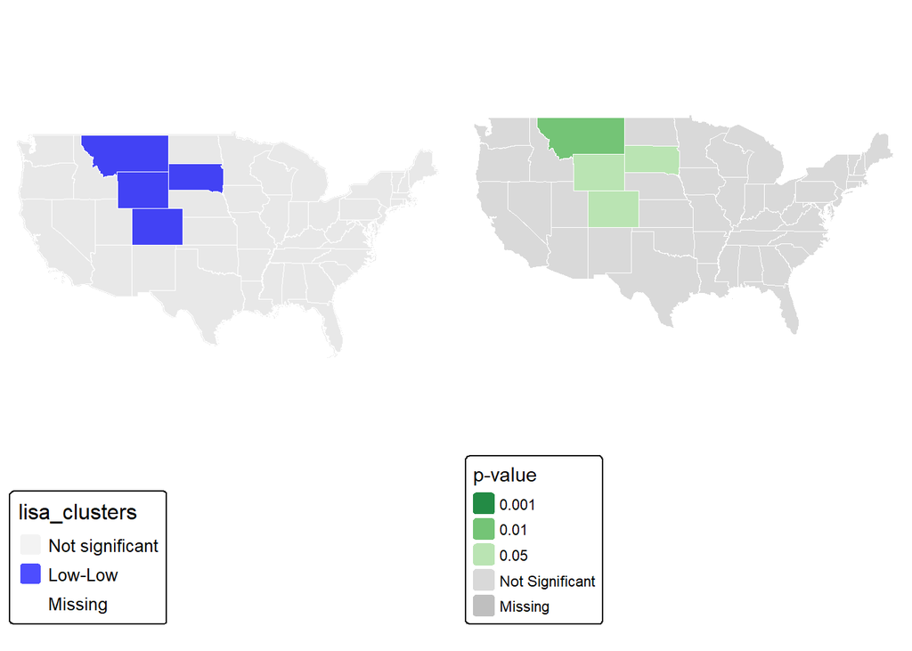

```r
tmap_mode("plot")

tmap_arrange(lisa_value_map, sign_value_map, ncol = 2)
```

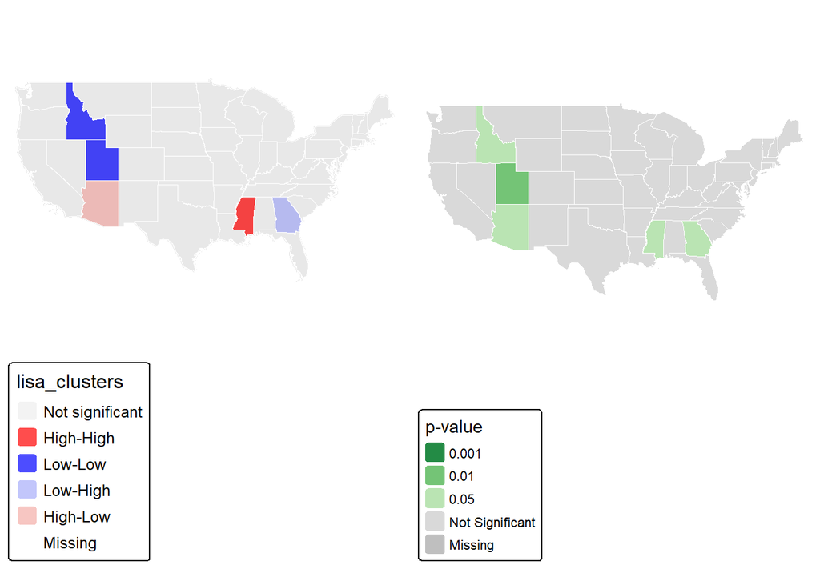

```r
tmap_arrange(lisa_atus_map, sign_atus_map, ncol = 2)
```

En conjunto, los resultados muestran que los clusters de empleo y de tiempo dedicado al relax y socialización no coinciden geográficamente. Los Estados con los valores más relevantes del gráfico de dispersión no coinciden entre las variables, y los mapas locales indican que no existe una relación espacial significativa entre el trabajo y el ocio a nivel estatal en Estados Unidos. En definitiva, los estados con altos niveles de empleo no necesariamente presentan bajos niveles de relax, y viceversa, resaltando la independencia relativa de estas dos variables a nivel estatal.